# Biostat 203B Homework 4

Due Mar 24 @ 11:59PM

Author

Cordelia Lee UID:105361901

Load database libraries and the tidyverse frontend:

```r
suppressPackageStartupMessages(library(tidyverse))
suppressPackageStartupMessages(library(tidymodels))
suppressPackageStartupMessages(library(lubridate))
suppressPackageStartupMessages(library(glmnet))
```

## 1 Predicting 30-day mortality

Using the ICU cohort `icu_cohort.rds` you built in Homework 3, develop at least three analytic approaches for predicting the 30-day mortality of patients admitted to ICU using demographic information (gender, age, marital status, ethnicity), first lab measurements during ICU stay, and first vital measurements during ICU stay. For example, you can use (1) logistic regression with elastic net (lasso + ridge) penalty (e.g., glmnet or keras package), (2) random forest, (3) boosting, and (4) support vector machines, or (5) MLP neural network (keras package)

1. Partition data into 50% training set and 50% test set. Stratify partitioning according the 30-day mortality status.

```r
library(GGally)
library(gtsummary)
library(ranger)
library(tidyverse)
library(tidymodels)
library(GGally)
library(xgboost)
# load the data "icu_cohort"
icu_cohort <- read_rds("mimiciv_shiny/icu_cohort.rds")%>%
# only keep the variables wanted. discarded those with a lot NAs
select ("gender", "marital_status", "ethnicity",
        "thirty_day_mort", "item_50912", "item_50971", "item_50912",
        "item_50971", "item_50983", "item_50902", "item_50882", "item_51221",
        "item_51301", "item_50931", "item_220045", "item_220181",
        "item_220179", "item_223761", "item_220210")

set.seed(203)

#splitting data
data_split <- initial_split(
  icu_cohort,
  # stratify by thirty day mortality
  strata = "thirty_day_mort",
  prop = 0.5
  )
data_split
```

```
<Training/Testing/Total>
<26532/26533/53065>
```

```r
icu_cohort_other <- training(data_split)
dim(icu_cohort_other)
```

```
[1] 26532    17
```

```r
icu_cohort_test <- testing(data_split)
dim(icu_cohort_test)
```

```
[1] 26533    17
```

## 2 Logistic Regression

2. Train and tune the models using the training set.

```r
logit_recipe <-
  recipe(
    thirty_day_mort ~ .,
    data = icu_cohort
  ) %>%
  # ignore missing data and impute because sample size is large
  # only impute the variables of interest
   step_impute_mode(marital_status, ethnicity, gender) %>%
   step_impute_mean(item_50912, item_50971, item_50912,
       item_50971,
       item_50983,
      item_50902,
      item_50882,
      item_51221,
      item_51301,
      item_50931,
     item_220045,
      item_220181,
      item_220179,
      item_223761,
      item_220210)%>%
  # create traditional dummy variables
  step_dummy(all_nominal_predictors()) %>%
  # zero-variance filter
  step_zv(all_numeric_predictors()) %>%
  # center and scale numeric data
  step_normalize(all_numeric_predictors()) %>%
  # estimate the means and standard deviations
  prep(training = icu_cohort_other, retain = TRUE)
logit_recipe
```

Model

```r
logit_mod <-
  logistic_reg(
    penalty = tune(),
    mixture = tune()
  ) %>%
  set_engine("glmnet", standardize = FALSE)
logit_mod
```

```
Logistic Regression Model Specification (classification)

Main Arguments:
  penalty = tune()
  mixture = tune()

Engine-Specific Arguments:
  standardize = FALSE

Computational engine: glmnet
```

Workflow

```r
logit_wf <- workflow() %>%
  add_recipe(logit_recipe) %>%
  add_model(logit_mod)
logit_wf
```

```
══ Workflow ════════════════════════════════════════════════════════════════════
Preprocessor: Recipe
Model: logistic_reg()

── Preprocessor ────────────────────────────────────────────────────────────────
5 Recipe Steps

• step_impute_mode()
• step_impute_mean()
• step_dummy()
• step_zv()
• step_normalize()

── Model ───────────────────────────────────────────────────────────────────────
Logistic Regression Model Specification (classification)

Main Arguments:
  penalty = tune()
  mixture = tune()

Engine-Specific Arguments:
  standardize = FALSE

Computational engine: glmnet
```

Tuning grid

```r
param_grid <- grid_regular(
  penalty(range = c(-6, 3)),
  mixture(),
  levels = c(100, 5)
  )
param_grid
```

```
# A tibble: 500 × 2
      penalty mixture
        <dbl>   <dbl>
 1 0.000001         0
 2 0.00000123       0
 3 0.00000152       0
 4 0.00000187       0
 5 0.00000231       0
 6 0.00000285       0
 7 0.00000351       0
 8 0.00000433       0
 9 0.00000534       0
10 0.00000658       0
# … with 490 more rows
```

Cross-validation

```r
set.seed(203)

folds <- vfold_cv(icu_cohort_other, v = 5)
folds
```

```
#  5-fold cross-validation
# A tibble: 5 × 2
  splits               id
  <list>               <chr>
1 <split [21225/5307]> Fold1
2 <split [21225/5307]> Fold2
3 <split [21226/5306]> Fold3
4 <split [21226/5306]> Fold4
5 <split [21226/5306]> Fold5
```

fit CV

```r
#str(icu_cohort)
logit_fit <- logit_wf %>%
  tune_grid(
    resamples = folds,
    grid = param_grid,
    metrics = metric_set(roc_auc, accuracy)
    )
logit_fit
```

```
# Tuning results
# 5-fold cross-validation
# A tibble: 5 × 4
  splits               id    .metrics             .notes
  <list>               <chr> <list>               <list>
1 <split [21225/5307]> Fold1 <tibble [1,000 × 6]> <tibble [0 × 3]>
2 <split [21225/5307]> Fold2 <tibble [1,000 × 6]> <tibble [0 × 3]>
3 <split [21226/5306]> Fold3 <tibble [1,000 × 6]> <tibble [0 × 3]>
4 <split [21226/5306]> Fold4 <tibble [1,000 × 6]> <tibble [0 × 3]>
5 <split [21226/5306]> Fold5 <tibble [1,000 × 6]> <tibble [0 × 3]>
```

```
# A tibble: 1,000 × 8
      penalty mixture .metric  .estimator  mean     n std_err
        <dbl>   <dbl> <chr>    <chr>      <dbl> <int>   <dbl>
 1 0.000001         0 accuracy binary     0.900     5 0.00117
 2 0.000001         0 roc_auc  binary     0.775     5 0.00711
 3 0.00000123       0 accuracy binary     0.900     5 0.00117
 4 0.00000123       0 roc_auc  binary     0.775     5 0.00711
 5 0.00000152       0 accuracy binary     0.900     5 0.00117
 6 0.00000152       0 roc_auc  binary     0.775     5 0.00711
 7 0.00000187       0 accuracy binary     0.900     5 0.00117
 8 0.00000187       0 roc_auc  binary     0.775     5 0.00711
 9 0.00000231       0 accuracy binary     0.900     5 0.00117
10 0.00000231       0 roc_auc  binary     0.775     5 0.00711
   .config
   <chr>
 1 Preprocessor1_Model001
 2 Preprocessor1_Model001
 3 Preprocessor1_Model002
 4 Preprocessor1_Model002
 5 Preprocessor1_Model003
 6 Preprocessor1_Model003
 7 Preprocessor1_Model004
 8 Preprocessor1_Model004
 9 Preprocessor1_Model005
10 Preprocessor1_Model005
# … with 990 more rows
```

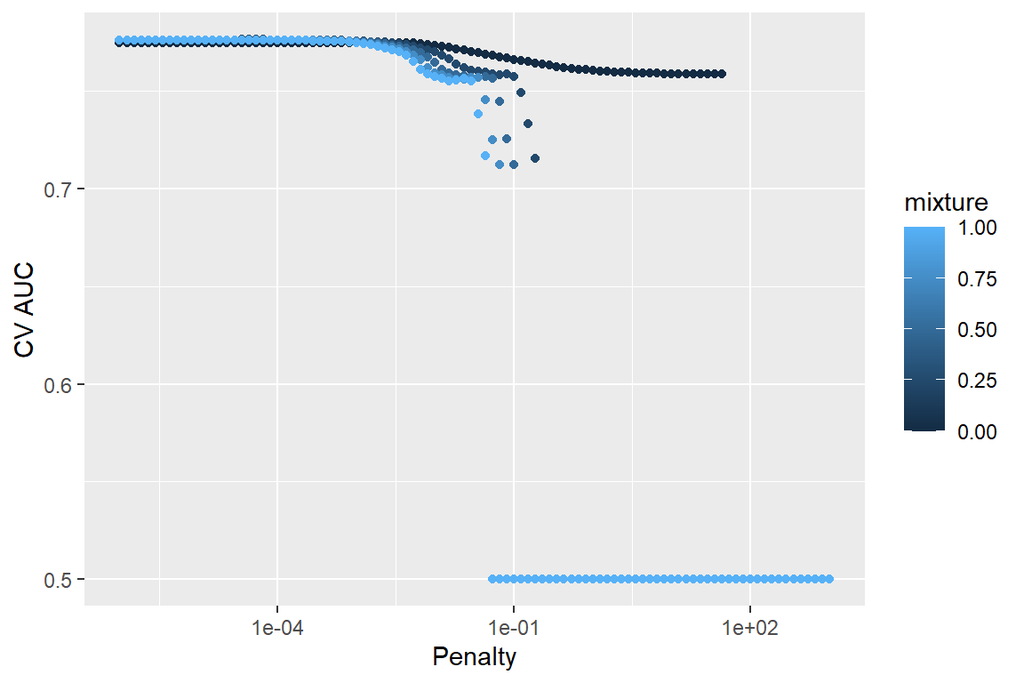

```r
logit_fit %>%
  collect_metrics() %>%
  print(width = Inf) %>%
  filter(.metric == "roc_auc") %>%
  ggplot(mapping = aes(x = penalty, y = mean, color = mixture)) +
  geom_point() +
  labs(x = "Penalty", y = "CV AUC") +
  scale_x_log10()
```

```r
logit_fit %>%
  show_best("roc_auc")
```

```
# A tibble: 5 × 8
    penalty mixture .metric .estimator  mean     n std_err .config
      <dbl>   <dbl> <chr>   <chr>      <dbl> <int>   <dbl> <chr>
1 0.0000433    0.25 roc_auc binary     0.776     5 0.00747 Preprocessor1_Model1…
2 0.0000351    0.25 roc_auc binary     0.776     5 0.00746 Preprocessor1_Model1…
3 0.0000534    0.25 roc_auc binary     0.776     5 0.00747 Preprocessor1_Model1…
4 0.0000658    0.25 roc_auc binary     0.776     5 0.00747 Preprocessor1_Model1…
5 0.0000285    0.25 roc_auc binary     0.776     5 0.00745 Preprocessor1_Model1…
```

```r
best_logit <- logit_fit %>%
  select_best("roc_auc")
best_logit
```

```
# A tibble: 1 × 3
    penalty mixture .config
      <dbl>   <dbl> <chr>
1 0.0000433    0.25 Preprocessor1_Model119
```

```r
best_logit <- logit_fit %>%
  select_best("roc_auc")
best_logit
```

```
# A tibble: 1 × 3
    penalty mixture .config
      <dbl>   <dbl> <chr>
1 0.0000433    0.25 Preprocessor1_Model119
```

```r
# Final workflow
final_wf <- logit_wf %>%
  finalize_workflow(best_logit)
final_wf
```

```
══ Workflow ════════════════════════════════════════════════════════════════════
Preprocessor: Recipe
Model: logistic_reg()

── Preprocessor ────────────────────────────────────────────────────────────────
5 Recipe Steps

• step_impute_mode()
• step_impute_mean()
• step_dummy()
• step_zv()
• step_normalize()

── Model ───────────────────────────────────────────────────────────────────────
Logistic Regression Model Specification (classification)

Main Arguments:
  penalty = 4.32876128108306e-05
  mixture = 0.25

Engine-Specific Arguments:
  standardize = FALSE

Computational engine: glmnet
```

```r
# Fit the whole training set, then predict the test cases
final_fit <-
  final_wf %>%
  last_fit(data_split)
final_fit
```

```
# Resampling results
# Manual resampling
# A tibble: 1 × 6
  splits                id               .metrics .notes   .predict…¹ .workflow
  <list>                <chr>            <list>   <list>   <list>     <list>
1 <split [26532/26533]> train/test split <tibble> <tibble> <tibble>   <workflow>
# … with abbreviated variable name ¹.predictions
```

```r
# Test metrics
final_fit %>%
  collect_metrics()
```

```
# A tibble: 2 × 4
  .metric  .estimator .estimate .config
  <chr>    <chr>          <dbl> <chr>
1 accuracy binary         0.900 Preprocessor1_Model1
2 roc_auc  binary         0.777 Preprocessor1_Model1
```

##Random Forest

```r
rf_recipe <-
  recipe(
    thirty_day_mort ~.,
    data = icu_cohort_other
  ) %>%
  # create traditional dummy variables (not necessary for random forest in R)
  # step_dummy(all_nominal()) %>%
 step_impute_mode(marital_status, ethnicity, gender) %>%
   step_impute_mean(item_50912, item_50971, item_50912,
    item_50971,
     item_50983,
      item_50902,
      item_50882,
      item_51221,
      item_51301,
      item_50931,
     item_220045,
      item_220181,
      item_220179,
      item_223761,
      item_220210) %>%
  # zero-variance filter
  step_zv(all_numeric_predictors()) %>%
  # # center and scale numeric data (not necessary for random forest)
  # step_normalize(all_numeric_predictors()) %>%
  # estimate the means and standard deviations
  prep(training = icu_cohort_other, retain = TRUE)
rf_recipe
```

Model

```r
rf_mod <-
  rand_forest(
    mode = "classification",
    # Number of predictors randomly sampled in each split
    mtry = tune(),
    # Number of trees in ensemble
    trees = tune()
  ) %>%
  set_engine("ranger")
rf_mod
```

```
Random Forest Model Specification (classification)

Main Arguments:
  mtry = tune()
  trees = tune()

Computational engine: ranger
```

```r
rf_wf <- workflow() %>%
  add_recipe(rf_recipe) %>%
  add_model(rf_mod)
rf_wf
```

```
══ Workflow ════════════════════════════════════════════════════════════════════
Preprocessor: Recipe
Model: rand_forest()

── Preprocessor ────────────────────────────────────────────────────────────────
3 Recipe Steps

• step_impute_mode()
• step_impute_mean()
• step_zv()

── Model ───────────────────────────────────────────────────────────────────────
Random Forest Model Specification (classification)

Main Arguments:
  mtry = tune()
  trees = tune()

Computational engine: ranger
```

Tuning grid

```r
param_grid <- grid_regular(
  trees(range = c(100L, 300L)),
  mtry(range = c(1L, 5L)),
  levels = c(3, 5)
  )
param_grid
```

```
# A tibble: 15 × 2
   trees  mtry
   <int> <int>
 1   100     1
 2   200     1
 3   300     1
 4   100     2
 5   200     2
 6   300     2
 7   100     3
 8   200     3
 9   300     3
10   100     4
11   200     4
12   300     4
13   100     5
14   200     5
15   300     5
```

Cross validation

```r
rf_fit <- rf_wf %>%
  tune_grid(
    resamples = folds,
    grid = param_grid,
    metrics = metric_set(roc_auc, accuracy)
    )
rf_fit
```

```
# Tuning results
# 5-fold cross-validation
# A tibble: 5 × 4
  splits               id    .metrics          .notes
  <list>               <chr> <list>            <list>
1 <split [21225/5307]> Fold1 <tibble [30 × 6]> <tibble [0 × 3]>
2 <split [21225/5307]> Fold2 <tibble [30 × 6]> <tibble [0 × 3]>
3 <split [21226/5306]> Fold3 <tibble [30 × 6]> <tibble [0 × 3]>
4 <split [21226/5306]> Fold4 <tibble [30 × 6]> <tibble [0 × 3]>
5 <split [21226/5306]> Fold5 <tibble [30 × 6]> <tibble [0 × 3]>
```

```
# A tibble: 30 × 8
    mtry trees .metric  .estimator  mean     n std_err .config
   <int> <int> <chr>    <chr>      <dbl> <int>   <dbl> <chr>
 1     1   100 accuracy binary     0.904     5 0.00182 Preprocessor1_Model01
 2     1   100 roc_auc  binary     0.864     5 0.00268 Preprocessor1_Model01
 3     1   200 accuracy binary     0.904     5 0.00137 Preprocessor1_Model02
 4     1   200 roc_auc  binary     0.867     5 0.00280 Preprocessor1_Model02
 5     1   300 accuracy binary     0.904     5 0.00144 Preprocessor1_Model03
 6     1   300 roc_auc  binary     0.867     5 0.00252 Preprocessor1_Model03
 7     2   100 accuracy binary     0.912     5 0.00172 Preprocessor1_Model04
 8     2   100 roc_auc  binary     0.866     5 0.00199 Preprocessor1_Model04
 9     2   200 accuracy binary     0.914     5 0.00161 Preprocessor1_Model05
10     2   200 roc_auc  binary     0.867     5 0.00281 Preprocessor1_Model05
# … with 20 more rows
```

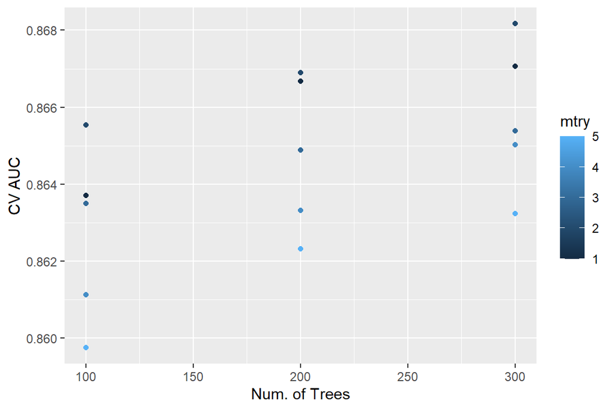

```r
rf_fit %>%
  collect_metrics() %>%
  print(width = Inf) %>%
  filter(.metric == "roc_auc") %>%
  ggplot(mapping = aes(x = trees, y = mean, color = mtry)) +
  geom_point() +
  # geom_line() +
  labs(x = "Num. of Trees", y = "CV AUC")
```

```r
rf_fit %>%
  show_best("roc_auc")
```

```
# A tibble: 5 × 8
   mtry trees .metric .estimator  mean     n std_err .config
  <int> <int> <chr>   <chr>      <dbl> <int>   <dbl> <chr>
1     2   300 roc_auc binary     0.868     5 0.00273 Preprocessor1_Model06
2     1   300 roc_auc binary     0.867     5 0.00252 Preprocessor1_Model03
3     2   200 roc_auc binary     0.867     5 0.00281 Preprocessor1_Model05
4     1   200 roc_auc binary     0.867     5 0.00280 Preprocessor1_Model02
5     2   100 roc_auc binary     0.866     5 0.00199 Preprocessor1_Model04
```

```r
best_rf <- rf_fit %>%
  select_best("roc_auc")
best_rf
```

```
# A tibble: 1 × 3
   mtry trees .config
  <int> <int> <chr>
1     2   300 Preprocessor1_Model06
```

Finalizing Model

```r
# Final workflow
final_wf <- rf_wf %>%
  finalize_workflow(best_rf)
final_wf
```

```
══ Workflow ════════════════════════════════════════════════════════════════════
Preprocessor: Recipe
Model: rand_forest()

── Preprocessor ────────────────────────────────────────────────────────────────
3 Recipe Steps

• step_impute_mode()
• step_impute_mean()
• step_zv()

── Model ───────────────────────────────────────────────────────────────────────
Random Forest Model Specification (classification)

Main Arguments:
  mtry = 2
  trees = 300

Computational engine: ranger
```

```r
# Fit the whole training set, then predict the test cases
final_fit <-
  final_wf %>%
  last_fit(data_split)
final_fit
```

```
# Resampling results
# Manual resampling
# A tibble: 1 × 6
  splits                id               .metrics .notes   .predict…¹ .workflow
  <list>                <chr>            <list>   <list>   <list>     <list>
1 <split [26532/26533]> train/test split <tibble> <tibble> <tibble>   <workflow>
# … with abbreviated variable name ¹.predictions
```

```r
# Test metrics
final_fit %>%
  collect_metrics()
```

```
# A tibble: 2 × 4
  .metric  .estimator .estimate .config
  <chr>    <chr>          <dbl> <chr>
1 accuracy binary         0.914 Preprocessor1_Model1
2 roc_auc  binary         0.869 Preprocessor1_Model1
```

##XGBoost Data summary

```r
# Numerical summaries stratified by the outcome `AHD`.
icu_cohort %>% tbl_summary(by = thirty_day_mort)
```

| **Characteristic** | **FALSE**, N = 47,558<sup>1</sup> | **TRUE**, N = 5,507<sup>1</sup> |
| --- | --- | --- |
| gender |  |  |
| F | 20,765 (44%) | 2,549 (46%) |
| M | 26,793 (56%) | 2,958 (54%) |
| marital_status |  |  |
| DIVORCED | 3,376 (7.7%) | 319 (7.2%) |
| MARRIED | 21,929 (50%) | 2,183 (49%) |
| SINGLE | 13,085 (30%) | 1,086 (24%) |
| WIDOWED | 5,603 (13%) | 867 (19%) |
| Unknown | 3,565 | 1,052 |
| ethnicity |  |  |
| AMERICAN INDIAN/ALASKA NATIVE | 87 (0.2%) | 7 (0.1%) |
| ASIAN | 1,392 (2.9%) | 169 (3.1%) |
| BLACK/AFRICAN AMERICAN | 4,466 (9.4%) | 401 (7.3%) |
| HISPANIC/LATINO | 1,697 (3.6%) | 124 (2.3%) |
| OTHER | 2,305 (4.8%) | 225 (4.1%) |
| UNABLE TO OBTAIN | 628 (1.3%) | 127 (2.3%) |
| UNKNOWN | 4,630 (9.7%) | 1,181 (21%) |
| WHITE | 32,353 (68%) | 3,273 (59%) |
| item_50912 | 1.00 (0.80, 1.40) | 1.70 (1.00, 3.00) |
| Unknown | 1,342 | 448 |
| item_50971 | 4.40 (4.10, 4.80) | 4.80 (4.30, 5.50) |
| Unknown | 1,330 | 439 |
| item_50983 | 140.0 (138.0, 143.0) | 142.0 (138.0, 147.0) |
| Unknown | 1,331 | 438 |
| item_50902 | 107 (104, 110) | 108 (103, 113) |
| Unknown | 1,329 | 441 |
| item_50882 | 26.0 (23.0, 28.0) | 24.0 (20.0, 28.0) |
| Unknown | 1,350 | 448 |
| item_51221 | 34.4 (30.7, 38.3) | 33.6 (29.5, 38.2) |
| Unknown | 1,399 | 458 |
| item_51301 | 12 (9, 17) | 16 (11, 23) |
| Unknown | 1,537 | 467 |
| item_50931 | 141 (115, 181) | 186 (144, 258) |
| Unknown | 1,441 | 452 |
| item_220045 | 104 (92, 120) | 122 (106, 140) |
| Unknown | 13 | 2 |
| item_220181 | 103 (91, 118) | 103 (89, 119) |
| Unknown | 443 | 261 |
| item_220179 | 148 (132, 165) | 148 (129, 168) |
| Unknown | 420 | 263 |
| item_223761 | 99.10 (98.60, 100.00) | 99.70 (98.60, 101.40) |
| Unknown | 476 | 477 |
| item_220210 | 29 (25, 34) | 33 (28, 39) |
| Unknown | 54 | 8 |

<sup>1</sup> n (%); Median (IQR)

```r
gb_recipe <-
  recipe(
    thirty_day_mort ~ .,
    data = icu_cohort_other
  ) %>%
 step_impute_mode(marital_status, ethnicity, gender) %>%
   step_impute_mean(item_50912, item_50971, item_50912,
       item_50971,
     item_50983,
      item_50902,
      item_50882,
      item_51221,
      item_51301,
      item_50931,
     item_220045,
      item_220181,
      item_220179,
      item_223761,
      item_220210) %>%
  step_dummy(all_nominal_predictors()) %>%
  # zero-variance filter
  step_zv(all_numeric_predictors()) %>%
  # estimate the means and standard deviations
  prep(training = icu_cohort_other, retain = TRUE)
gb_recipe
```

Model

```r
gb_mod <-
  boost_tree(
    mode = "classification",
    trees = 1000,
    tree_depth = tune(),
    learn_rate = tune()
  ) %>%
  set_engine("xgboost")
gb_mod
```

```
Boosted Tree Model Specification (classification)

Main Arguments:
  trees = 1000
  tree_depth = tune()
  learn_rate = tune()

Computational engine: xgboost
```

Workflow and pipeline

```r
gb_wf <- workflow() %>%
  add_recipe(gb_recipe) %>%
  add_model(gb_mod)
gb_wf
```

```
══ Workflow ════════════════════════════════════════════════════════════════════
Preprocessor: Recipe
Model: boost_tree()

── Preprocessor ────────────────────────────────────────────────────────────────
4 Recipe Steps

• step_impute_mode()
• step_impute_mean()
• step_dummy()
• step_zv()

── Model ───────────────────────────────────────────────────────────────────────
Boosted Tree Model Specification (classification)

Main Arguments:
  trees = 1000
  tree_depth = tune()
  learn_rate = tune()

Computational engine: xgboost
```

Tuning grid

```r
param_grid <- grid_regular(
  tree_depth(range = c(1L, 3L)),
  learn_rate(range = c(-5, 2), trans = log10_trans()),
  levels = c(3, 10)
  )
param_grid
```

```
# A tibble: 30 × 2
   tree_depth learn_rate
        <int>      <dbl>
 1          1  0.00001
 2          2  0.00001
 3          3  0.00001
 4          1  0.0000599
 5          2  0.0000599
 6          3  0.0000599
 7          1  0.000359
 8          2  0.000359
 9          3  0.000359
10          1  0.00215
# … with 20 more rows
```

```r
gb_fit <- gb_wf %>%
  tune_grid(
    resamples = folds,
    grid = param_grid,
    metrics = metric_set(roc_auc, accuracy)
    )
gb_fit
```

```
# Tuning results
# 5-fold cross-validation
# A tibble: 5 × 4
  splits               id    .metrics          .notes
  <list>               <chr> <list>            <list>
1 <split [21225/5307]> Fold1 <tibble [60 × 6]> <tibble [0 × 3]>
2 <split [21225/5307]> Fold2 <tibble [60 × 6]> <tibble [0 × 3]>
3 <split [21226/5306]> Fold3 <tibble [60 × 6]> <tibble [0 × 3]>
4 <split [21226/5306]> Fold4 <tibble [60 × 6]> <tibble [0 × 3]>
5 <split [21226/5306]> Fold5 <tibble [60 × 6]> <tibble [0 × 3]>
```

Visualize results

```
# A tibble: 60 × 8
   tree_depth learn_rate .metric  .estimator  mean     n std_err
        <int>      <dbl> <chr>    <chr>      <dbl> <int>   <dbl>
 1          1  0.00001   accuracy binary     0.896     5 0.00165
 2          1  0.00001   roc_auc  binary     0.677     5 0.00225
 3          2  0.00001   accuracy binary     0.898     5 0.00171
 4          2  0.00001   roc_auc  binary     0.729     5 0.00461
 5          3  0.00001   accuracy binary     0.900     5 0.00145
 6          3  0.00001   roc_auc  binary     0.749     5 0.00175
 7          1  0.0000599 accuracy binary     0.896     5 0.00165
 8          1  0.0000599 roc_auc  binary     0.677     5 0.00225
 9          2  0.0000599 accuracy binary     0.898     5 0.00198
10          2  0.0000599 roc_auc  binary     0.738     5 0.00320
   .config
   <chr>
 1 Preprocessor1_Model01
 2 Preprocessor1_Model01
 3 Preprocessor1_Model02
 4 Preprocessor1_Model02
 5 Preprocessor1_Model03
 6 Preprocessor1_Model03
 7 Preprocessor1_Model04
 8 Preprocessor1_Model04
 9 Preprocessor1_Model05
10 Preprocessor1_Model05
# … with 50 more rows
```

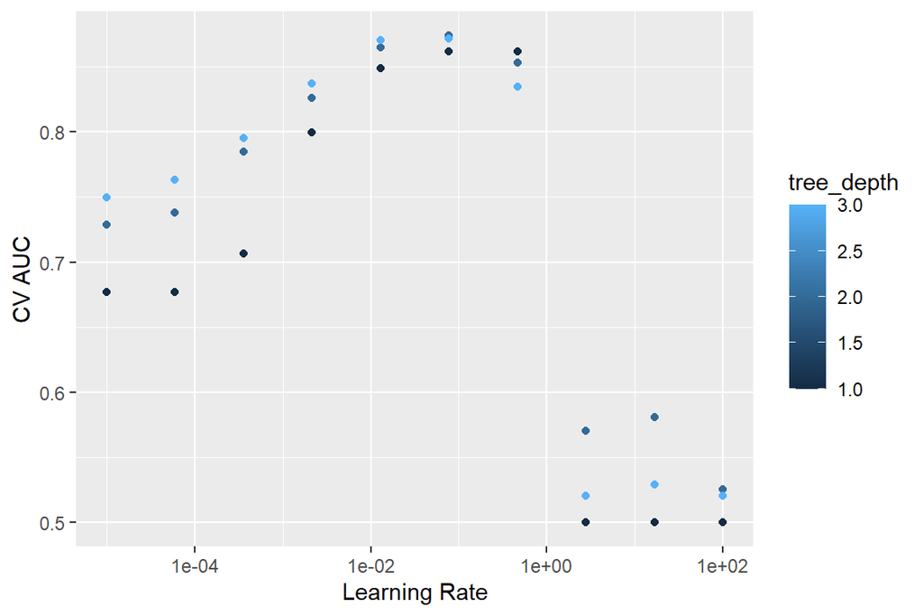

```r
gb_fit %>%
  collect_metrics() %>%
  print(width = Inf) %>%
  filter(.metric == "roc_auc") %>%
  ggplot(mapping = aes(x = learn_rate, y = mean, color = tree_depth)) +
  geom_point() +
  labs(x = "Learning Rate", y = "CV AUC") +
  scale_x_log10()
```

```r
gb_fit %>%
  show_best("roc_auc")
```

```
# A tibble: 5 × 8
  tree_depth learn_rate .metric .estimator  mean     n std_err .config
       <int>      <dbl> <chr>   <chr>      <dbl> <int>   <dbl> <chr>
1          2     0.0774 roc_auc binary     0.874     5 0.00283 Preprocessor1_Mo…
2          3     0.0774 roc_auc binary     0.872     5 0.00252 Preprocessor1_Mo…
3          3     0.0129 roc_auc binary     0.871     5 0.00257 Preprocessor1_Mo…
4          2     0.0129 roc_auc binary     0.865     5 0.00244 Preprocessor1_Mo…
5          1     0.464  roc_auc binary     0.862     5 0.00266 Preprocessor1_Mo…
```

select the best model

```r
best_gb <- gb_fit %>%
  select_best("roc_auc")
best_gb
```

```
# A tibble: 1 × 3
  tree_depth learn_rate .config
       <int>      <dbl> <chr>
1          2     0.0774 Preprocessor1_Model17
```

finalize our model

```r
# Final workflow
final_wf <- gb_wf %>%
  finalize_workflow(best_gb)
final_wf
```

```
══ Workflow ════════════════════════════════════════════════════════════════════
Preprocessor: Recipe
Model: boost_tree()

── Preprocessor ────────────────────────────────────────────────────────────────
4 Recipe Steps

• step_impute_mode()
• step_impute_mean()
• step_dummy()
• step_zv()

── Model ───────────────────────────────────────────────────────────────────────
Boosted Tree Model Specification (classification)

Main Arguments:
  trees = 1000
  tree_depth = 2
  learn_rate = 0.0774263682681127

Computational engine: xgboost
```

```r
# Fit the whole training set, then predict the test cases
final_fit <-
  final_wf %>%
  last_fit(data_split)
final_fit
```

```
# Resampling results
# Manual resampling
# A tibble: 1 × 6
  splits                id               .metrics .notes   .predict…¹ .workflow
  <list>                <chr>            <list>   <list>   <list>     <list>
1 <split [26532/26533]> train/test split <tibble> <tibble> <tibble>   <workflow>
# … with abbreviated variable name ¹.predictions
```

```r
# Test metrics
final_fit %>%
  collect_metrics()
```

```
# A tibble: 2 × 4
  .metric  .estimator .estimate .config
  <chr>    <chr>          <dbl> <chr>
1 accuracy binary         0.916 Preprocessor1_Model1
2 roc_auc  binary         0.873 Preprocessor1_Model1
```

From the three models selected, it appears that XGBoost has the highest ROC_AUC and has a slightly higher accuracy than random forest.